# Donor Profile: Spain (Government of)

## Transaction Volatility

Spain’s average transaction amount stands at $600.4K across 32.3 annual transactions, markedly lower than the top 10 donors benchmark averaging $2.9M per transaction and 586.9 transactions per year. This significant funding scale gap constrains our capacity to leverage critical emergency response and resilience initiatives. The volatile transaction pattern over 97 data points highlights inconsistent funding flows, creating risks to program continuity and impact sustainability. Investing in scaling Spain’s transaction volume represents a strategic priority to unlock an impact multiplier effect, bridging funding gaps to meet urgent operational needs and amplify innovation in targeted interventions. Leveraging this insight, we urge donors and partnerships to prioritize sustained, high-frequency transactions with Spain, enhancing predictability for programme planning and risk mitigation. Immediate executive focus on strengthening bilateral coordination and transaction monitoring will optimize resource allocation, enhancing accountability and donor confidence. Mobilizing increased funding volume from Spain not only secures essential program continuity but also amplifies strategic leverage for UNHCR’s transformative impact.

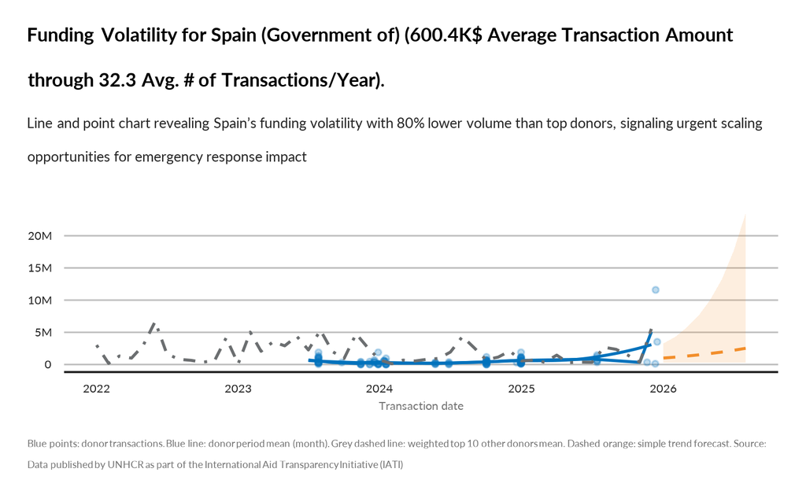

TRUE